# Hw 3

Xiang Yang Ng

May 5, 2018

Set the current directory, clear the environment and download the libraries

```r
setwd("C:/Users/Xiang/OneDrive/Desktop/Econ-144/Homework/Hw 3")

rm(list=ls(all=TRUE))

library("quantmod")
library(lattice)
library(foreign)
library(MASS)
library(car)
require(stats)
require(stats4)
library(KernSmooth)
library(fastICA)
library(cluster)
library(leaps)
library(mgcv)
library(rpart)
library(pan)
library(mgcv)
library(DAAG)
library("TTR")
library(tis)
```

```r
require("datasets")
require(graphics)
library("forecast")
#install.packages("astsa")
#require(astsa)
library(xtable)
# New libraries added:
library(stats)
library(TSA)
```

```
## locfit 1.5-9.1    2013-03-22
```

```r
library(timeSeries)
library(fUnitRoots)
library(fBasics)
library(tseries)
library(timsac)
library(TTR)
library(fpp)
```

# Problem 1

Clear the environment

```r
rm(list = ls(all=TRUE))
```

1. Obtaining the theoretical ACF

```r
ARMAacf(ma = c(-2, 1.35), lag.max = 10)
```

```
##          0          1          2          3          4          5
##  1.0000000 -0.6888970  0.1978747  0.0000000  0.0000000  0.0000000
##          6          7          8          9         10
##  0.0000000  0.0000000  0.0000000  0.0000000  0.0000000
```

2. Obtaining the simulated MA(2) model with 100 points and it’s ACF. Running this simulation 10 times

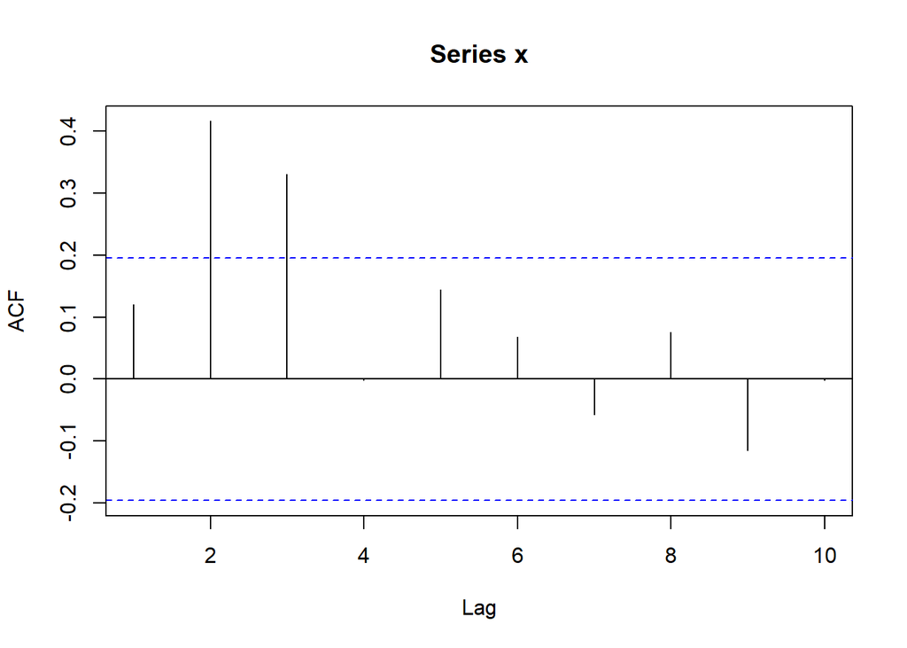

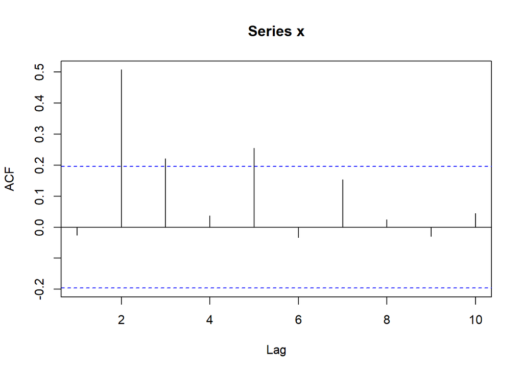

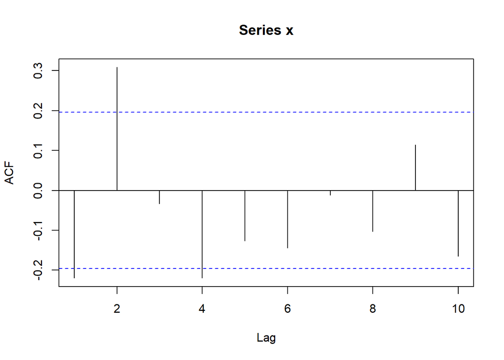

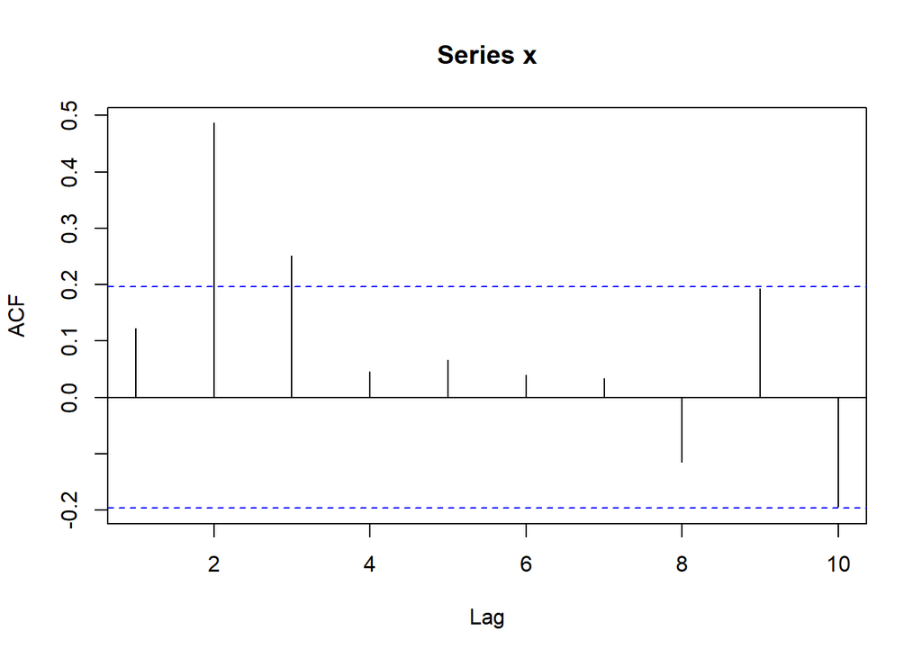

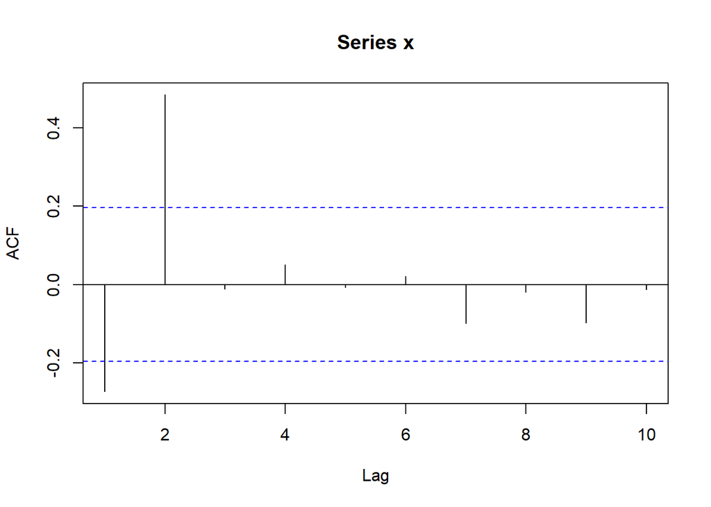

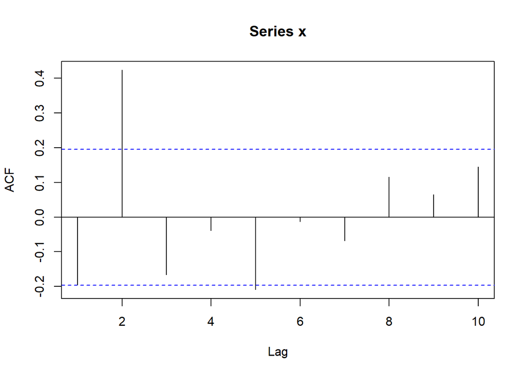

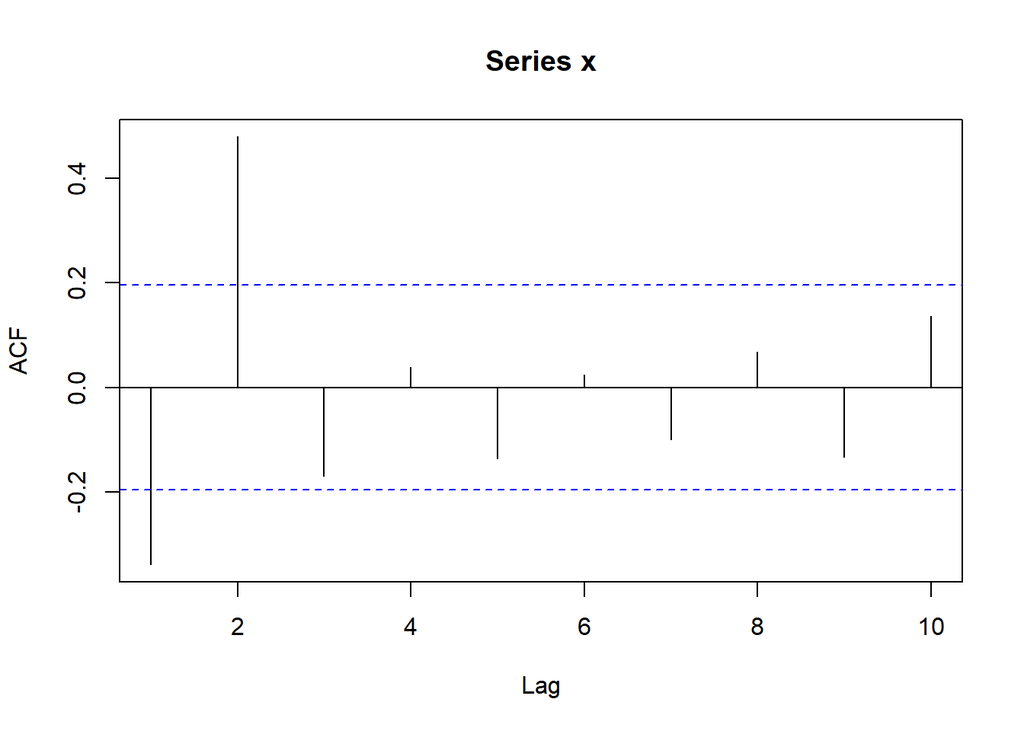

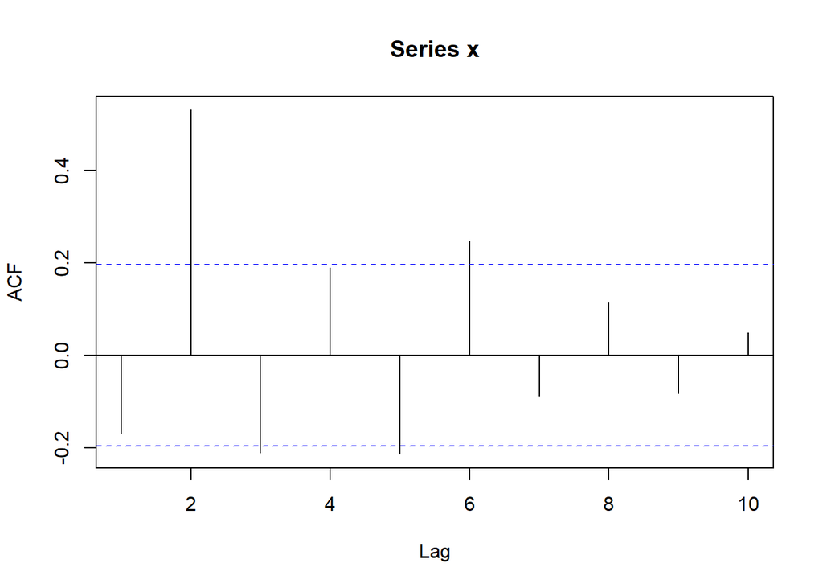

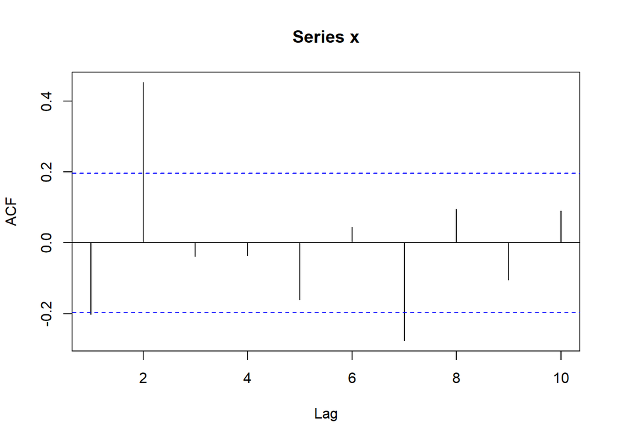

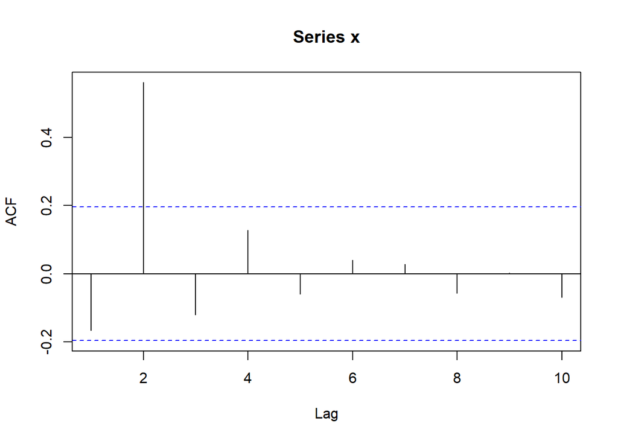

```r
for (i in 1:10){
  x = e = rnorm(100)
  x[2] = 0.7 -0.2*e[1] + e[2]
  for (t in 3:100) x[t] = 0.7-0.2*e[t-1]+1.35*e[t-2] + e[t]
  acf(x, lag.max = 10)
}
```

# Problem 2

Clear the previous data and obtain the data

```r
rm(list = ls(all = TRUE))
data = read.csv("6.10.csv")
names(data) = c("date", "ApplPrice", "return")
attach(data)
```

First look at the plots for both the price and the returns, as well as their ACF and PACF

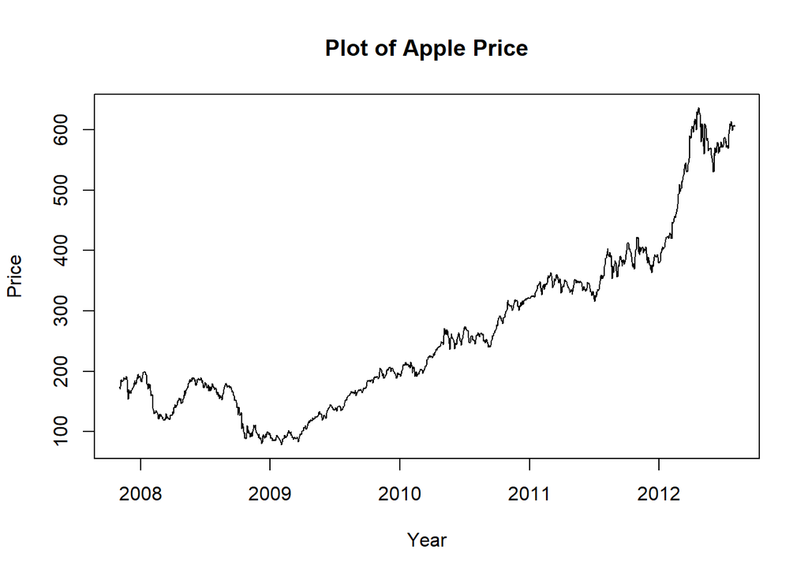

```r
ApplPrice_ts = ts(ApplPrice, start = 2007+(10/12), end = 2012 + (7/12), freq = 252)
return_ts = ts(return, start = 2007+(10/12), end = 2012 + (7/12), freq = 252)
plot(ApplPrice_ts, type = "l", main = "Plot of Apple Price", xlab = "Year", ylab = "Price")
```

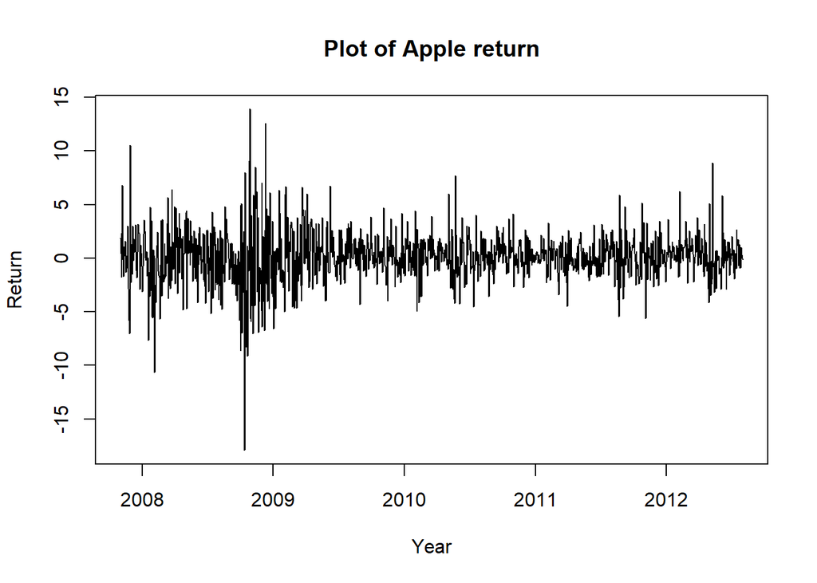

```r
plot(return_ts, type = "l", main = "Plot of Apple return", xlab = "Year", ylab = "Return")
```

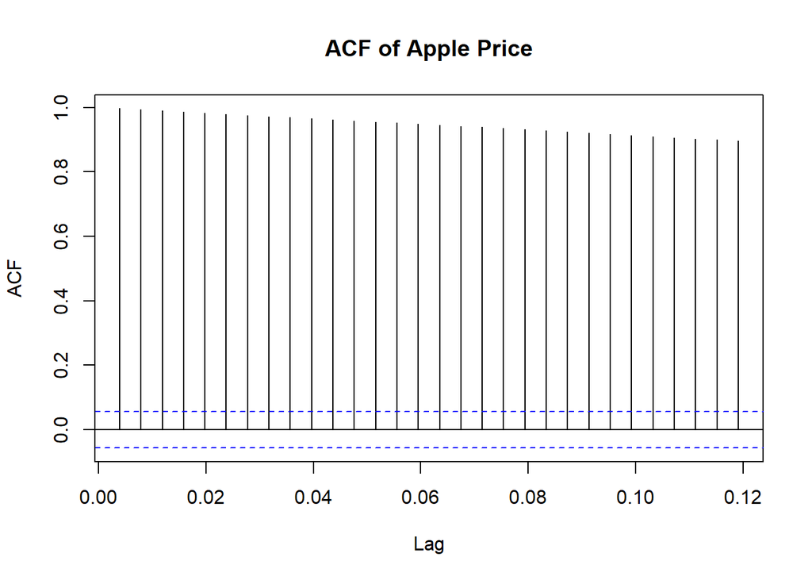

```r
acf(ApplPrice_ts, main = "ACF of Apple Price", type = "correlation")
```

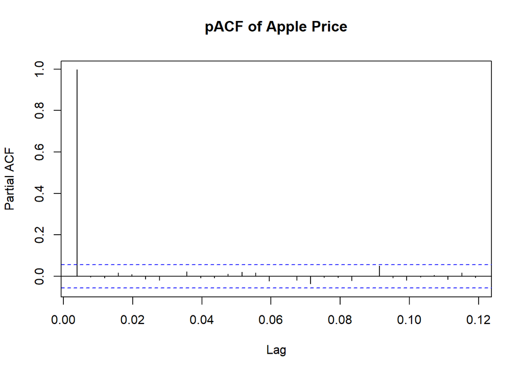

```r
pacf(ApplPrice_ts, main = "pACF of Apple Price")
```

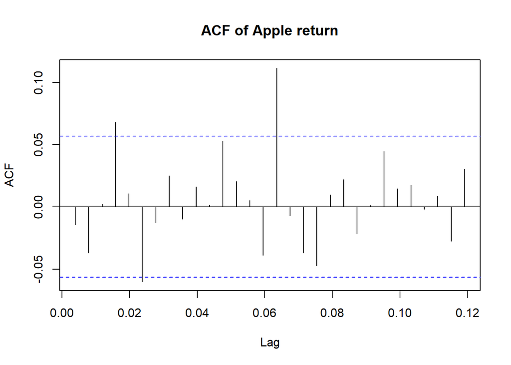

```r
acf(return_ts, main = "ACF of Apple return")
```

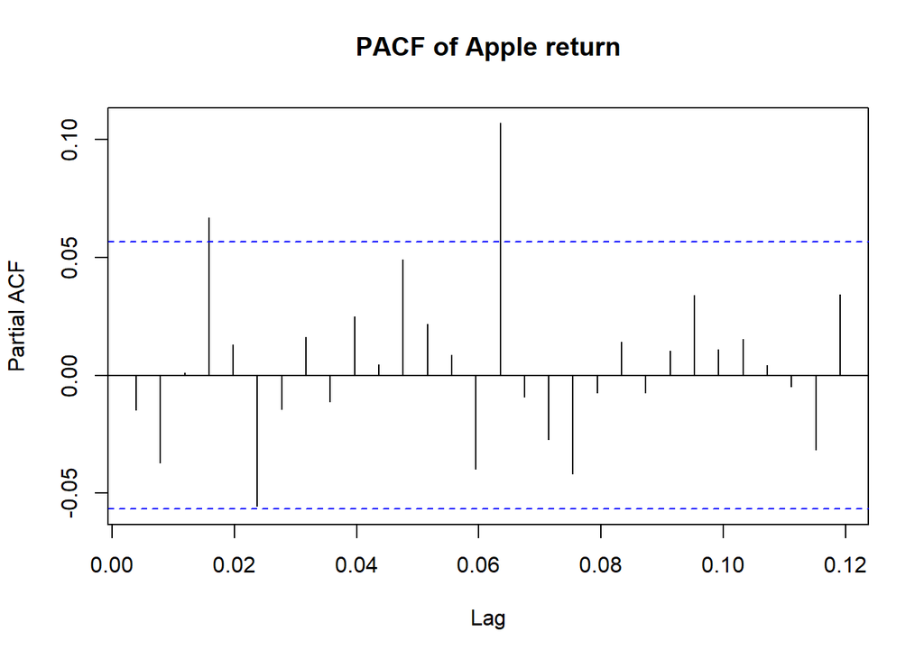

```r
pacf(return_ts, main = "PACF of Apple return")
```

Looking at the plot of the price, there is an upward trend, while the ACF shows a slow decay and the PACF shows one spike. This means we should take the first difference of the price and then fit an AR(1) model to the data. Then we take the ACF and PACF of the residuals of the AR(1) model and also do the Box-Pierce test on it to test for time dependence between values of different lags.

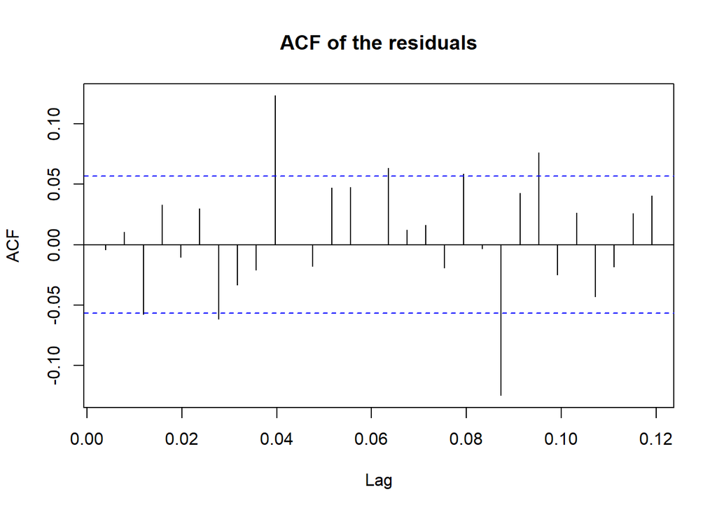

```r
ar1 = Arima(ApplPrice_ts, order = c(1,1,0))
acf(ar1$residuals, main = "ACF of the residuals")
```

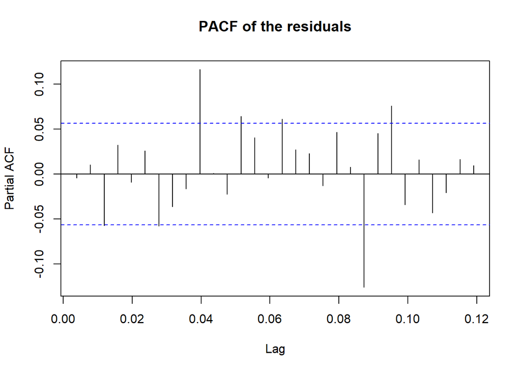

```r
pacf(ar1$residuals, main = "PACF of the residuals")
```

```r
Box.test(ar1$residuals)
```

```
##
##  Box-Pierce test
##
## data:  ar1$residuals
## X-squared = 0.0229, df = 1, p-value = 0.8797
```

```r
ar1.pred = forecast(ar1, h = 10)
print("The point forecast for the 10-step ahead is as follows:")
```

```
## [1] "The point forecast for the 10-step ahead is as follows:"
```

```r
print(ar1.pred$mean)
```

```
## Time Series:
## Start = c(2012, 149)
## End = c(2012, 158)
## Frequency = 252
##  [1] 606.2544 606.2544 606.2544 606.2544 606.2544 606.2544 606.2544
##  [8] 606.2544 606.2544 606.2544
```

```r
print(paste("While the value at the last observation is", toString(ar1$fitted[length(ar1$fitted)])))
```

```
## [1] "While the value at the last observation is 606.940246817187"
```

The values of the 10 step ahead point forecast are the same, which actually coincides with theory, since for mean is 0 and the persistence is 1, the point forecast for k-steps ahead at time t will just approximate to the realized value at time t.

# Problem 3

Clear the previous data and obtain the new data

```r
rm(list = ls(all=TRUE))
data = read.csv("7.2.csv")
names(data) = c('date', 'unemploy_thousands')
attach(data)
```

To explain the difference in acf or pacf, we need to look at the plot of the data

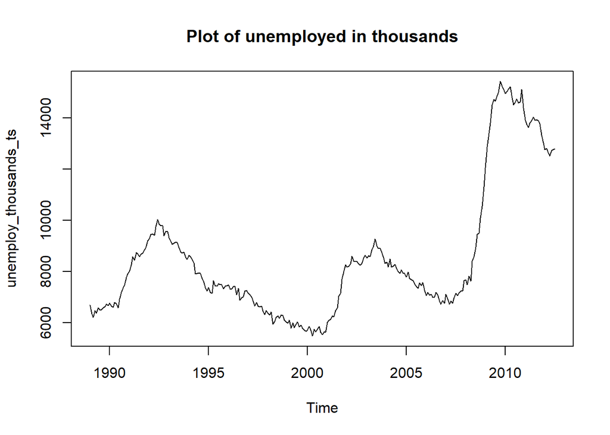

```r
unemploy_thousands_ts = ts(unemploy_thousands, start = 1989, freq = 12)
plot(unemploy_thousands_ts, main = "Plot of unemployed in thousands")
```

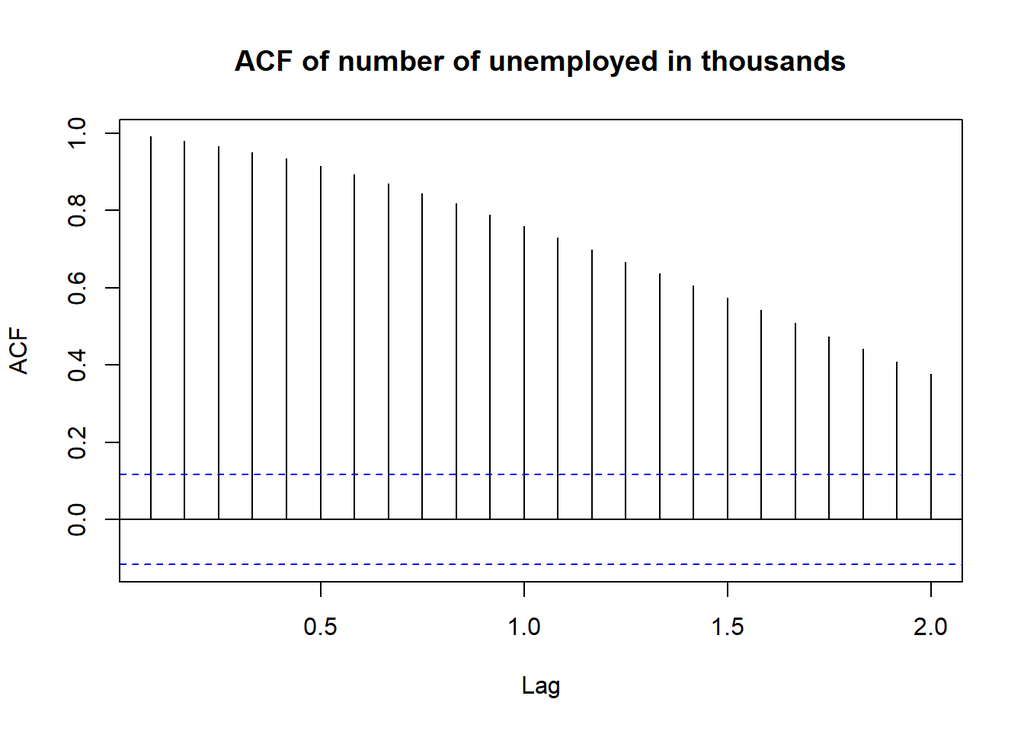

```r
unemploy_thousands_ts = ts(unemploy_thousands, start = 1989, frequency = 12)

acf(unemploy_thousands_ts, main = "ACF of number of unemployed in thousands")
```

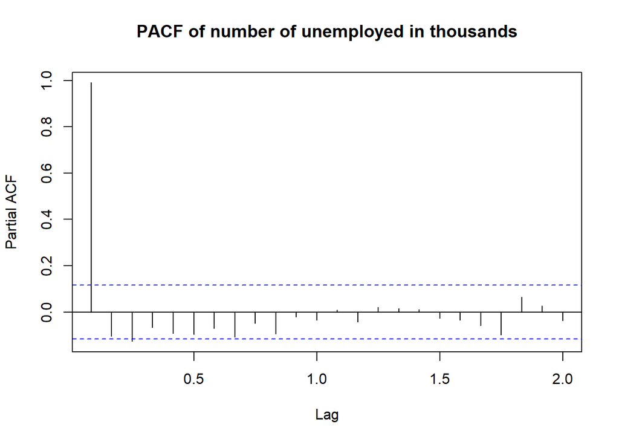

```r
pacf(unemploy_thousands_ts, main = "PACF of number of unemployed in thousands")
```

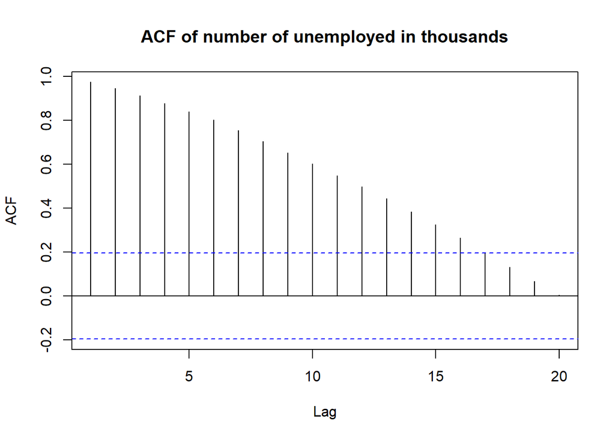

```r
acf(unemploy_thousands_ts[1:100], main = "ACF of number of unemployed in thousands")
```

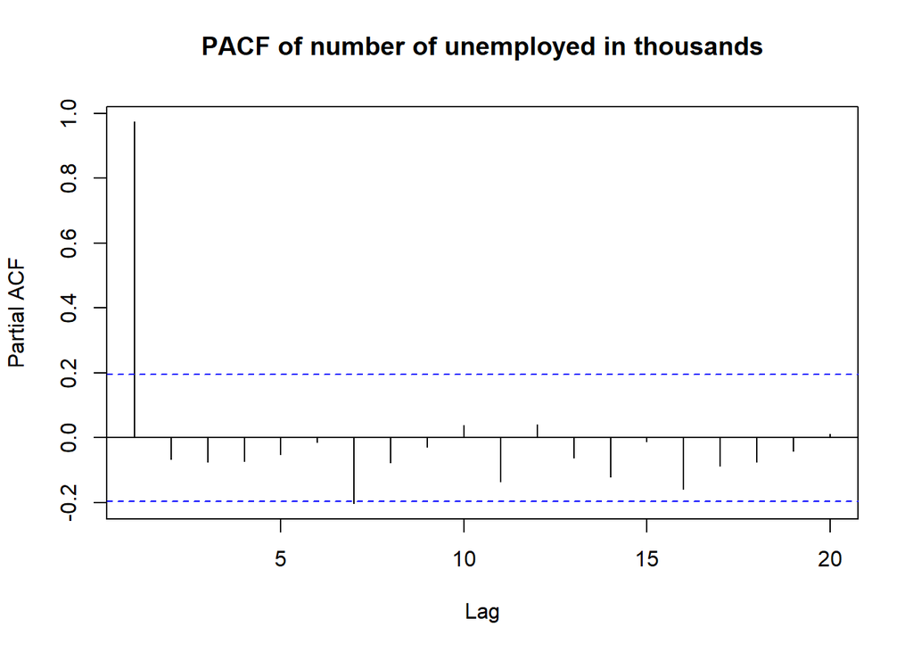

```r
pacf(unemploy_thousands_ts[1:100], main = "PACF of number of unemployed in thousands")
```

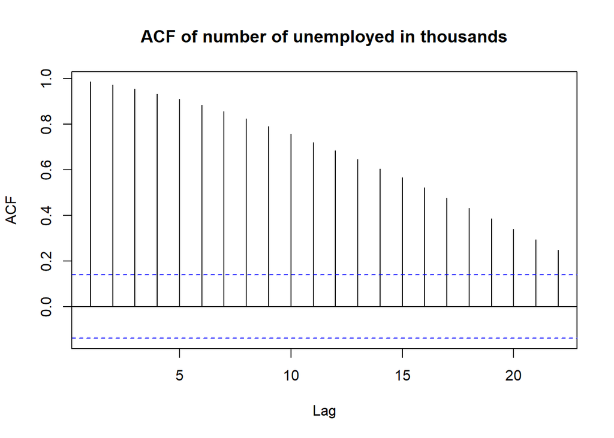

```r
acf(unemploy_thousands_ts[2:200], main = "ACF of number of unemployed in thousands")
```

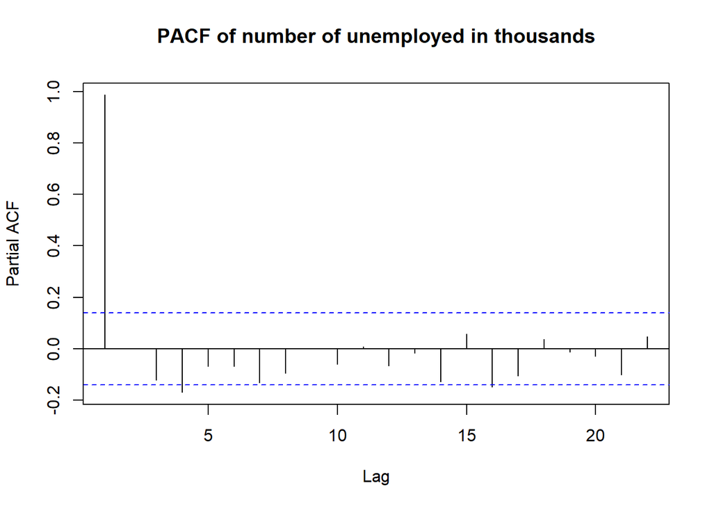

```r
pacf(unemploy_thousands_ts[2:200], main = "PACF of number of unemployed in thousands")
```

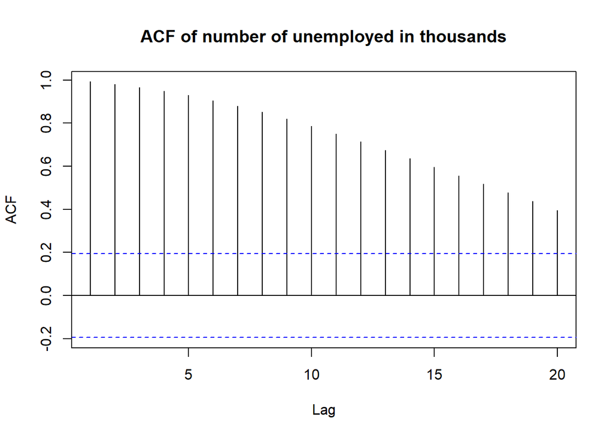

```r
acf(unemploy_thousands_ts[183:283], main = "ACF of number of unemployed in thousands")
```

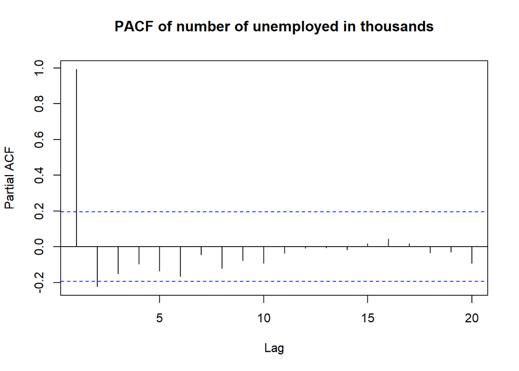

```r
pacf(unemploy_thousands_ts[183:283], main = "PACF of number of unemployed in thousands")
```

From the ACFs, there is a slow decay as the lag value increases and for each of the PACF, we can see there is a signifcant time dependence with lag 1 and that there seems to be a significant time dependence with other lags which is much smaller in magnitude compared to the first lag in various other lags. This means that there seems that for the time spans that I choose, there seems to be not much variation in the significance of the time dependence for for all lags.

AR model is also good to fit the data since there is a few spikes in the PACF and a decay of the ACF as lag values increases.

## Problem 4

Clear all the previous environment and add in the new data

```r
rm(list = ls(all=TRUE))
data = read.csv("7.6.csv")
names(data)[c(3,5)] = c("housing.inflation", "transportation.inflation")
attach(data)
```

```r
hinf_ts = ts(housing.inflation, start = 1976, freq = 1)
tinf_ts = ts(transportation.inflation, start = 1976, freq = 1)
```

To understand whether the data can be modeled as an AR(2) process, we have to look at the ACF and PACF of all the percentage change time series objects

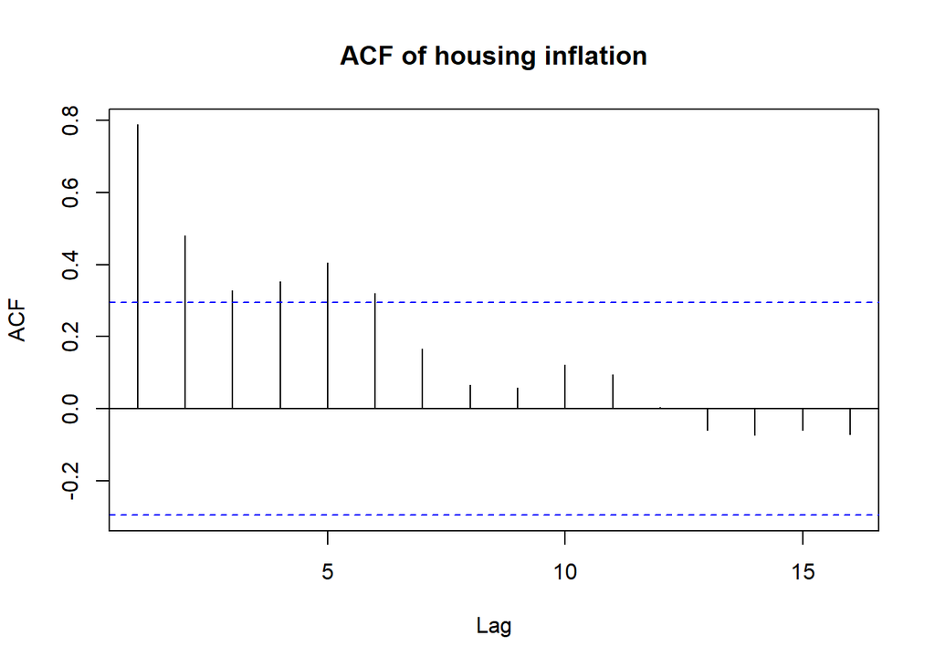

```r
acf(hinf_ts[complete.cases(hinf_ts)], main = "ACF of housing inflation")
```

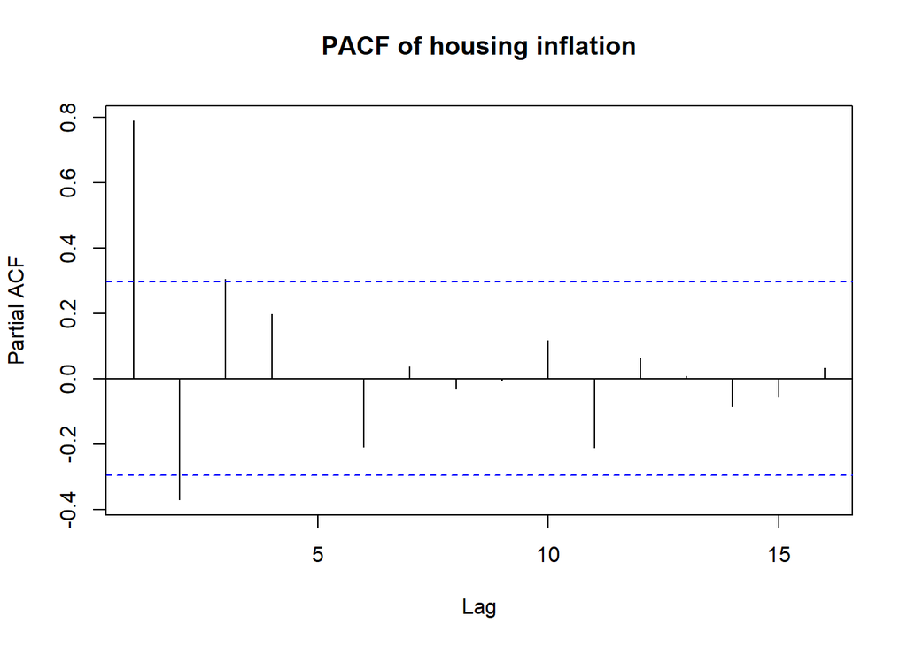

```r
pacf(hinf_ts[complete.cases(hinf_ts)],  main = "PACF of housing inflation")
```

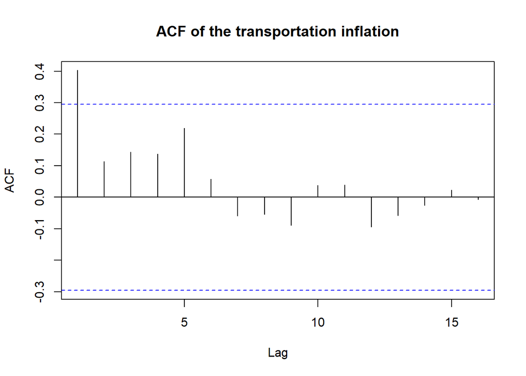

```r
acf(tinf_ts[complete.cases(tinf_ts)], main = "ACF of the transportation inflation")
```

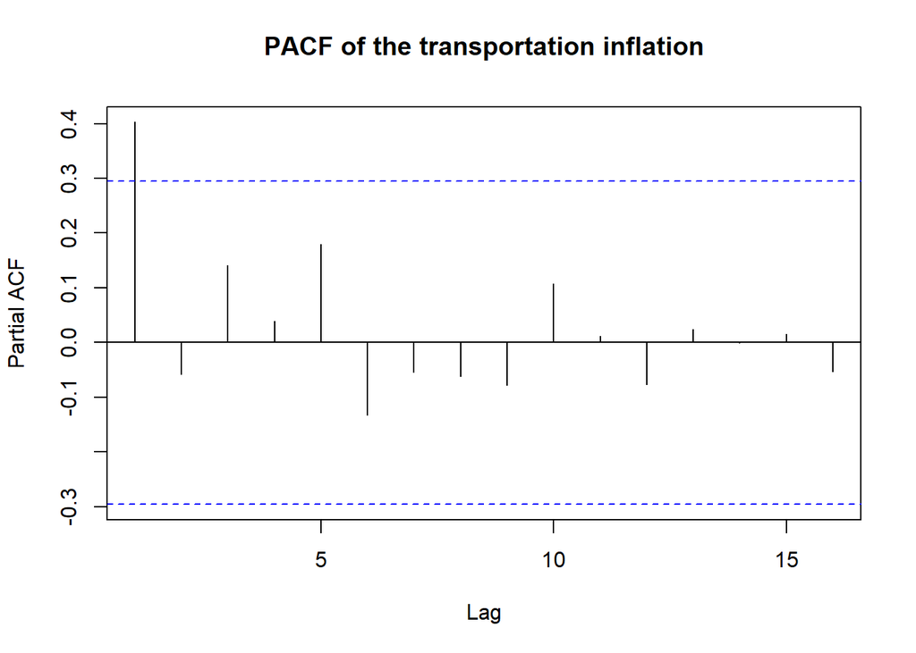

```r
pacf(tinf_ts[complete.cases(tinf_ts)],  main = "PACF of the transportation inflation")
```

Based on the ACF and PACF, since there are 3 spikes for housing inflation, which means that we might be able to fit the AR(2), while since there is only 1 spike for the transporation inflation, which means we might not be able to fit it.